# Educational Attainment and Adult Depression

Raine Zhuang

2026-04-14

# I. Introduction

Depression is one of the leading causes of disease burden in high-income countries, affecting nearly one in three U.S. adults over their lifetime (Kessler et al., 2012). The economic costs are substantial, with lost productivity and healthcare expenses totaling hundreds of billions annually. If educational attainment can reduce depressive symptoms, then policies that expand college access may generate meaningful mental health benefits alongside their well-documented economic returns.

A large body of research documents that individuals with higher levels of education report fewer depressive symptoms (Lorant et al., 2003; Mirowsky and Ross, 2003). However, it remains unclear whether this relationship is causal. The same characteristics that predict college completion—cognitive ability, family support, good adolescent mental health—also predict lower depression in adulthood. If these unobserved factors explain the association, then policies promoting college enrollment may not deliver the expected mental health improvements.

This study examines whether completing a college degree is associated with lower depressive symptoms in a nationally representative sample of U.S. young adults. Using data from the National Longitudinal Survey of Youth 1997 (NLSY97) and ordinary least squares regression with extensive controls, I find that college graduates report fewer depressive symptoms than non-graduates on average. The estimated association (-0.770 on a 21-point CES-D scale) is robust to the inclusion of exogenous controls and is substantially attenuated when post-treatment mediators (employment, income, health) are added, suggesting that education’s protective effect operates largely through labor market and health pathways. While causal claims require additional testing and stronger identification, the results are consistent with education having a meaningful protective effect on mental health.

# II. Background

A large body of research documents that individuals with higher levels of educational attainment report fewer depressive symptoms (Lorant et al., 2003; Mirowsky and Ross, 2003; Miech et al., 2005; Quesnel-Vallée and Taylor, 2012). This inverse association is remarkably consistent across U.S. and international samples, leading many scholars to conceptualize education as a protective factor against depression.

However, the policy relevance of the education–depression relationship depends on whether it represents a causal effect or merely a correlation driven by unobserved selection factors. The concern is that the same individual characteristics that predict educational attainment—cognitive ability, conscientiousness, supportive families, good adolescent mental health—also predict lower depression in adulthood. If these unmeasured confounders explain the association, then policies that increase college enrollment may not generate the expected mental health benefits.

Recent studies have addressed the confounder problem using various identification strategies. Using propensity score matching, Bauldry (2015) found that college completion protects against depressive symptoms. Mezuk, Myers, and Kendler (2012) employed a genetically informed twin design and found that education and depression share a common genetic cause. McFarland and Wagner (2015) used a monozygotic twin discordant design and found that having a college degree was associated with 0.90 fewer depressive symptoms on a 12-point CES-D scale. However, their estimate comes from a sample of only 231 twin pairs, raising concerns about external validity. Twins may not represent the general population, as they differ in birth weight, early treatment by parents, and social experiences (Felson, 2014).

# III. Data

## A. Data Source and Sample

This study uses data from the National Longitudinal Survey of Youth 1997 (NLSY97), a nationally representative survey of U.S. individuals born between 1980 and 1984 conducted by the Bureau of Labor Statistics. The baseline interview in 1997 included 8,984 respondents aged 12-17, who have been followed through adulthood. The outcome variable is drawn from the 2023 interview wave (respondents aged 38-43).

## B. Variables

**Outcome variable.** Depressive symptoms are measured using the 7-item Center for Epidemiologic Studies Depression Scale (CES-D) from the 2023 wave. Items are summed to create a continuous score ranging from 0 to 21, where higher values indicate more severe depressive symptoms (Radloff, 1977).

**Main predictor.** Educational attainment is measured as the highest degree completed by 2021. Based on previous literature (Bauldry, 2015), this variable is collapsed into a binary indicator: High Degree (college degree or higher) versus Low Degree (lower than a college degree), coded as 1 and 0 respectively.

**Control variables.** All controls, except for age, are measured prior to 2023. These include sex (binary), age (continuous), parental education (continuous), race (White vs. non-White), negative peer influence (binary), urban residence (binary), personality traits (neuroticism, openness, extraversion), employment status (binary), partnership status (binary), and log income, and cognitive ability. Cognitive ability is measured by the ASVAB math-verbal percentile score, administered in 1997 (ages 12-17). The raw score (0-100,000) is converted to a 0-100 scale by dividing by 1000.

## C. Missing Data

Variables with no or minimal missingness are retained without imputation. For all other variables, multiple imputation using chained equations (MICE) is employed. Five imputed datasets are generated, and results are pooled using Rubin’s rules (Rubin, 1987).

# IV. Empirical Strategy

To estimate the association between educational attainment and depressive symptoms, I estimate three ordinary least squares (OLS) regression models.

## A. Baseline Model

The baseline specification is:

$$CESD_i = \beta_0 + \beta_1 HighDegree_i
+ \varepsilon_i$$

where $CESD_i$ is the CES-D depression score for respondent $i$, and $HighDegree_i$ is an indicator equal to 1 if the respondent has completed a college degree or higher. The coefficient $\beta_1$ estimates the difference in mean depressive symptoms between college graduates and non-graduates.

## B. Model with Exogenous Controls

To address omitted variable bias, I estimate a second model:

$$CESD_i = \beta_0 + \beta_1 HighDegree_i
+ \mathbf{X_i}\gamma + \varepsilon_i$$

where $\mathbf{X_i}$ includes demographic characteristics, socioeconomic background, adolescent peer environment, cognitive ability, and personality traits.

## C. Model with Full Controls

To investigate pathways between college completion and depressive symptoms, I estimate a third model:

$$CESD_i = \beta_0 + \beta_1 HighDegree_i
+ \mathbf{X_i}\gamma + \mathbf{Z_i}\alpha + \varepsilon_i$$

where $\mathbf{Z_i}$ includes prior depressive symptoms (CES-D 2019), employment status, partnership status, log income, and self-rated health.

## D. Identification Assumptions

Figure 1 shows the residuals versus fitted values plot and Q-Q plot of residuals for the no control model.

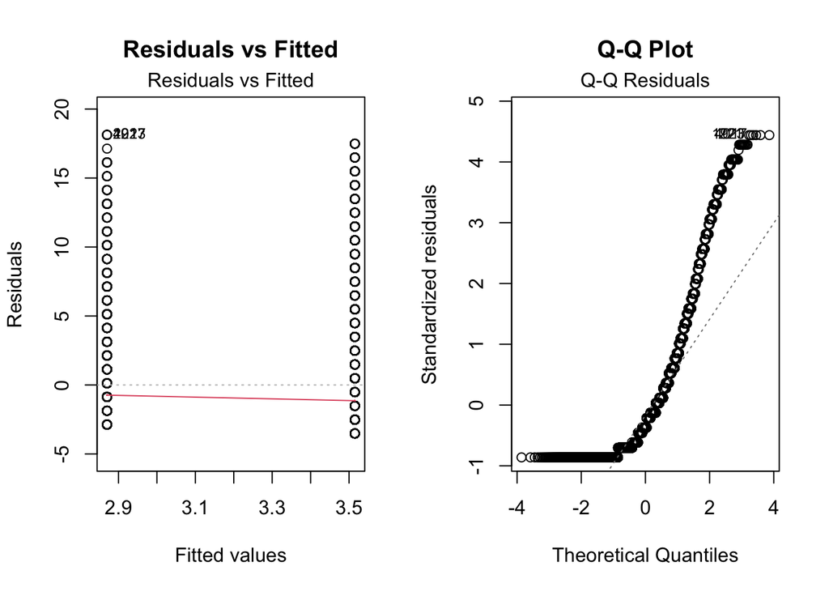

Residuals vs Fitted Plot and Q-Q Plot

# V. Results

## A. Main Findings

**Model 1 (No Controls).** Having a college degree is associated with a 0.689-point lower CES-D score (p < 0.001). This raw association aligns with the established education–depression gradient (Mirowsky and Ross, 2003; Lorant et al., 2003).

**Model 2 (Exogenous Controls).** Adding exogenous controls, the education coefficient becomes -0.770 (p < 0.001). Female respondents report CES-D scores 0.906 points higher than males (p < 0.001), consistent with documented gender differences (Rosenfield and Mouzon, 2013). Urban residents report higher depressive symptoms (0.442 points, p < 0.001). Negative peer influence predicts higher CES-D scores (0.361 points, p < 0.01). Neuroticism is associated with lower depression (-0.546, p < 0.001). The model explains approximately 7% of the variance (Adjusted R² = 0.068).

**Model 3 (Full Controls).** Adding post-treatment mediators attenuates the education coefficient to -0.161 (not significant). This attenuation is expected as these variables lie on the causal pathway. Significant coefficients for prior depression (0.469, p < 0.001), self-rated health (0.559, p < 0.001), and employment (-0.508, p < 0.001) suggest these are important mediators. The full model explains 31% of the variance (Adjusted R² = 0.311).

## B. Interpretation

Three conclusions emerge. First, there is a robust negative association between college completion and depressive symptoms that persists after controlling for exogenous variables. The coefficient in Model 2 (-0.770) represents approximately 80% of the gender gap in depression.

Second, the education coefficient is not sensitive to the inclusion of exogenous controls—its magnitude increases slightly from Model 1 to Model 2. This pattern is unusual; most studies find that adding controls attenuates the coefficient (Lee and Yang, 2022; McFarland and Wagner, 2015). This stability strengthens confidence that the association is not merely an artifact of omitted pre-existing differences.

Third, the sharp attenuation in Model 3 indicates that much of the education effect operates through post-education pathways such as employment and health.

# VI. Discussion

## A. Assessment of Results and Assumptions

The results show that completing a bachelor’s degree is associated with significantly lower depressive symptoms, even after controlling for an extensive set of pre-existing characteristics (Model 2: -0.770, p < 0.001). This finding is consistent with the broader literature (Mirowsky and Ross, 2003; Lorant et al., 2003; McFarland and Wagner, 2015; Bauldry, 2015).

**Strengths.** The NLSY97 offers two rare advantages. First, the ASVAB measure of adolescent cognitive ability addresses a key source of selection bias. Second, the longitudinal design ensures exogeneity of controls (Angrist and Pischke, 2009).

**Weaknesses.** Conditional independence remains untestable. Unobserved factors such as childhood trauma or genetic predispositions could still bias the estimate. The CES-D scale is self-reported and may be subject to reporting bias.

**Alternative explanations.** One important omitted variable is whether individuals have depression or other mental health conditions as a child, since this could affect their ability to complete any form of education and could also affect their mental health as an adult (both directly and indirectly through education).

## B. Extension: A Falsification Test Using Placebo Outcomes

To further assess whether the estimated association is plausibly causal, I propose a falsification test using a placebo outcome: respondent’s height in 1997 (measured at age 12-17). Height at adolescence is biologically determined and should not be influenced by college completion.

This test is feasible with existing data. Replacing CES-D score with height as the outcome while keeping all controls identical would provide evidence on residual confounding. A non-significant coefficient on college completion would strengthen the argument for a genuine causal effect.

# VII. Conclusion

**Limitations and future directions.** Unobserved confounding cannot be ruled out; a falsification test using adolescent height is proposed. The sample is restricted to a single cohort; replication using NLSY79 or more recent cohorts would assess generalizability. Finally, this study does not examine heterogeneity by gender, race, or socioeconomic background. Given Lee and Yang’s (2022) finding that education’s mental health benefits accrue primarily to women, future research should investigate subgroup variation.

**Policy implications.** If the association is causal, policies that expand college access—need-based financial aid, community college investments—may generate mental health benefits. Given that employment and income are important mediators, policies improving labor market outcomes for non-graduates offer alternative policy levers.

In summary, this study provides evidence that college completion is associated with lower depressive symptoms conditional on extensive controls.

# REFERENCES

Angrist, Joshua D., and Jörn-Steffen Pischke. 2009. *Mostly Harmless Econometrics: An Empiricist’s Companion*. Princeton: Princeton University Press.

Bauldry, Shawn. 2015. “Variation in the Protective Effect of Higher Education against Depression.” *Society and Mental Health* 5(2): 145–161.

Felson, Jacob. 2014. “What Can We Learn from Twin Studies? A Comprehensive Evaluation of the Equal Environments Assumption.” *Social Science Research* 43: 184–199.

Lee, Kristen Schultz, and Yulin Yang. 2022. “Educational Attainment and Emotional Well-Being in Adolescence and Adulthood.” *SSM - Mental Health* 2: 100138.

Lorant, Vincent, Denise Deliège, William Eaton, Alain Robert, Pierre Philippot, and Marc Ansseau. 2003. “Socioeconomic Inequalities in Depression: A Meta-Analysis.” *American Journal of Epidemiology* 157(2): 98–112.

McFarland, Michael J., and Brandon G. Wagner. 2015. “Does a College Education Reduce Depressive Symptoms in American Young Adults?” *Social Science & Medicine* 146: 75–84.

Mezuk, Briana, John M. Myers, and Kenneth S. Kendler. 2012. “Integrating Social Science and Behavioral Genetics: Testing the Origin of Socioeconomic Disparities in Depression Using a Genetically Informed Design.” *American Journal of Public Health* 103(S1): S145–S151.

Miech, Richard A., William W. Eaton, and Kerry Brennan. 2005. “Mental Health Disparities across Education and Sex: A Prospective Analysis Examining How They Persist over the Life Course.” *The Journals of Gerontology Series B: Psychological Sciences and Social Sciences* 60(Special Issue 2): S93–S98.

Mirowsky, John, and Catherine E. Ross. 2003. *Education, Social Status, and Health*. New York: Aldine de Gruyter.

Quesnel-Vallée, Amélie, and Miles Taylor. 2012. “Socioeconomic Pathways to Depressive Symptoms in Adulthood: Evidence from the National Longitudinal Survey of Youth 1979.” *Social Science & Medicine* 74(5): 734–743.

Radloff, Lenore Sawyer. 1977. “The CES-D Scale: A Self-Report Depression Scale for Research in the General Population.” *Applied Psychological Measurement* 1(3): 385–401.

Rosenfield, Sarah, and Dawne Mouzon. 2013. “Gender and Mental Health.” In *Handbook of the Sociology of Mental Health*, edited by Carol S. Aneshensel, Jo C. Phelan, and Alex Bierman, 277–296. Dordrecht: Springer Netherlands.

Rubin, Donald B. 1987. *Multiple Imputation for Nonresponse in Surveys*. New York: John Wiley & Sons.